# Primeros pasos en R y RStudio

Taller Introducción a R  
Centro Académico de Cómputos, Facultad de Ciencias Sociales

Dr. Rashid C. J. Marcano Rivera

Departamento de Sociología y Antropología  
Facultad de Ciencias Sociales, UPR-RP

13 de noviembre de 2026

# Bienvenida

## Sobre este taller

**Viernes 13 de noviembre de 2026, de 8:00 a 10:00, salón 118**

| Hora | Parte |
| --- | --- |
| 8:00 a 8:30 | **Panorama:** qué es R y para qué se usa |
| 8:30 a 9:50 | **Manos a la obra:** paso a paso en RStudio |
| 9:50 a 10:00 | Cierre, recursos y preguntas |

Seguimos dos libros gratuitos en español:

- Wickham, Çetinkaya-Rundel y Grolemund, [*R para la Ciencia de Datos*](https://davidrsch.github.io/r4ds-es/), 2.ª edición
- Irizarry, [*Introducción a la ciencia de datos*](https://rafalab.dfci.harvard.edu/dslibro/)

# Parte I: panorama

## R, RStudio y Quarto

| Herramienta | ¿Qué es? |
| --- | --- |
| **R** | El lenguaje de programación (el motor) |
| **RStudio** | La interfaz que facilita usar R (el tablero) |
| **Quarto** | El sistema para crear documentos que combinan texto, código y resultados |

- R es **gratuito** y de código abierto.
- Hoy hay **25,736 paquetes** en CRAN, el repositorio oficial: cada uno añade herramientas para una tarea.
- RStudio, de la empresa Posit, también es gratuito. [Posit Cloud](https://posit.cloud/) permite usarlo desde el navegador.

## ¿Por qué R en ciencias sociales?

- **Reproducibilidad:** cada paso queda escrito en un *script* que otra persona, o ustedes dentro de un año, puede volver a correr.
- **Costo:** no requiere licencia, ni en la UPR ni después de graduarse.
- **Amplitud:** estadística, gráficos, mapas, textos y documentos en un mismo lugar.
- **Comunidad:** libros, foros y materiales gratuitos, muchos en español.

## Lo que se puede hacer con R

| Tarea | Paquetes |
| --- | --- |
| Leer encuestas de SPSS, Stata y Excel | `haven`, `readxl` |
| Bajar datos del Censo y la ACS de Puerto Rico | `tidycensus` |
| Limpiar y transformar datos | `dplyr`, `tidyr` (del `tidyverse`) |
| Gráficos de calidad para publicación | `ggplot2` |
| Mapas y análisis espacial | `sf` |
| Análisis de textos | `tidytext`, `quanteda` |
| Recoger datos de páginas web | `rvest` |
| Aplicaciones interactivas | `shiny` |

## Quarto: un archivo, muchos formatos

Un documento de Quarto (`.qmd`) mezcla texto y código. Al **renderizarlo**, R corre el código y pega los resultados:

````markdown
---
title: "Mi primer informe"
format: html
---

La esperanza de vida promedio en 2010 fue de
`r round(mean(gapminder$life_expectancy[gapminder$year == 2010]), 1)` años.

```{r}
ggplot(gapminder, aes(fertility, life_expectancy)) + geom_point()
```
````

El mismo archivo produce **HTML, PDF, Word, presentaciones, sitios web y libros**. Esta presentación es un `.qmd`, y los dos libros que seguimos también están hechos con estas herramientas.

## Git y GitHub: control de versiones

- **Git** guarda un historial de los cambios de sus archivos: quién cambió qué, cuándo y por qué.
- **GitHub** guarda ese historial en la nube, para respaldar y colaborar.
- RStudio trae un panel de Git integrado: *commit* para guardar una versión, *push* para subirla.

Los materiales de mis talleres anteriores están en GitHub:

- [Taller del CACCS, abril de 2026](https://github.com/RashidCJ/Taller-CACCS-FCS-Abr-2026)
- [Taller del CRiiAS, febrero de 2026](https://github.com/RashidCJ/Taller-R-CRiiAS-UPRRP-Feb-2026)

Guía recomendada: [*Happy Git and GitHub for the useR*](https://happygitwithr.com/) (en inglés) y el capítulo 39 de Irizarry.

## Proyectos de RStudio

Un **proyecto** (`.Rproj`) es una carpeta con todo lo de un trabajo: datos, scripts, documentos y resultados.

- Al abrir el proyecto, R sabe dónde están los archivos: no hacen falta rutas como `C:/Users/...`.
- Cada trabajo queda separado de los demás.
- Funciona igual en cualquier computadora, y se conecta con Git.

## Si han usado SPSS, Stata o Excel

|  | SPSS / Stata | Excel | R |
| --- | --- | --- | --- |
| Costo | Licencia | Licencia | Gratuito |
| Registro del análisis | Sintaxis (opcional) | No | *Script* (siempre) |
| Gráficos | Limitados | Básicos | Muy flexibles |
| Mapas, textos, web | No | No | Sí |

R lee directamente los archivos `.sav` y `.dta`, con sus etiquetas de variables y valores.

## Sobre aprender R

- Los errores son normales: el mensaje de error trae información, hay que leerlo.
- Se aprende copiando, modificando y rompiendo código.

**Cuando se atasquen**

- `?función` o `help(función)`: la ayuda de R
- Las [hojas de referencia de Posit](https://rstudio.github.io/cheatsheets/): las de `dplyr`, `ggplot2`, `tidyr`, `readr` y `readxl`, en español, están en la carpeta `hojas-de-referencia` del repositorio
- Los capítulos de *R para la Ciencia de Datos* y de Irizarry

# Parte II: manos a la obra

## Paso 1: RStudio por dentro

Abran RStudio. Tiene cuatro paneles:

- **Fuente** (arriba a la izquierda): scripts y documentos
- **Consola** (abajo a la izquierda): donde R ejecuta el código
- **Ambiente** (arriba a la derecha): los objetos en memoria
- **Archivos, gráficos y ayuda** (abajo a la derecha)

**Una configuración, una sola vez**

*Tools → Global Options → General*: desmarquen «Restore .RData into workspace at startup» y escojan «Never» en «Save workspace to .RData on exit». Así cada sesión empieza limpia (recomendación de Irizarry, capítulo 1).

## Tildes y eñes: UTF-8

R acepta `año`, `educación` o `niño` en nombres de objetos y columnas, siempre que el archivo esté en **UTF-8**.

**Otra configuración, también una sola vez**

*Tools → Global Options → Code → Saving → Default text encoding*: escojan **UTF-8**. Desde entonces, todo script nuevo se guarda en UTF-8.

## Paso 2: crear un proyecto

1. *File → New Project → New Directory → New Project*
2. Nombre: `taller-r`. Ubicación: el Escritorio o Documentos.
3. *Create Project*

Noten que RStudio se reinicia y que el panel de archivos muestra la carpeta nueva, con el archivo `taller-r.Rproj`.

## Paso 3: R como calculadora

Escriban en la **consola** y opriman *Enter*:

```r
1 + 2
## [1] 3
13 / 2
## [1] 6.5
2 ^ 6
## [1] 64
sqrt(81)
## [1] 9
```

## Paso 4: un script

*File → New File → R Script*, y guárdenlo como `primeros-pasos.R`.

- Escriban el código en el script y ejecútenlo con **Ctrl + Enter** (Windows) o **Cmd + Return** (Mac).
- Lo que va después de `#` es un **comentario**: R no lo ejecuta.

```r
# Esto es un comentario: sirve para explicar el código
10 * 3   # también puede ir al final de una línea
## [1] 30
```

## Paso 5: objetos

Los **objetos** guardan valores para reutilizarlos. La flecha `<-` asigna:

```r
x <- 4
x + 2
## [1] 6

isla <- "Puerto Rico"   # texto, entre comillas
isla
## [1] "Puerto Rico"

bilingüe <- TRUE        # valor lógico
bilingüe
## [1] TRUE
```

**Buenas prácticas**

Nombres descriptivos y sin espacios: `edad_participante` es mejor que `x`. R acepta tildes y eñes en los nombres.

## Paso 6: vectores y funciones

`c()` junta valores en un **vector**. Las **funciones** reciben datos y devuelven un resultado:

```r
edades <- c(23, 31, 27, 45, 38, 22, 29)

mean(edades)    # media
## [1] 30.71429
sd(edades)      # desviación estándar
## [1] 8.260635
range(edades)   # mínimo y máximo
## [1] 22 45
length(edades)  # cuántos valores hay
## [1] 7
```

Prueben `?mean` para ver la ayuda, y `mean("texto")` para ver un error.

## Su turno (5 minutos)

1. Creen un vector `horas_sueño` con siete valores, uno por día de la semana.
2. Calculen la media, el mínimo (`min()`) y el máximo (`max()`).
3. Redondeen la media a un decimal con `round()`. Busquen en `?round` cómo indicar los decimales.

## Paso 7: paquetes

Se **instalan una vez** con `install.packages()` y se **cargan en cada sesión** con `library()`:

```r
install.packages(c("tidyverse", "dslabs"))   # una sola vez
```

```r
library(tidyverse)  # colección de paquetes para ciencia de datos
library(dslabs)     # datos del libro de Irizarry
data(gapminder)
```

## Paso 8: mirar los datos

`gapminder` tiene datos de unos 185 países de 1960 a 2016: población, esperanza de vida, fertilidad y PIB.

```r
glimpse(gapminder)
## Rows: 10,545
## Columns: 9
## $ country          <fct> "Albania", "Algeria", "Angola", "Antigua and Barbuda"…
## $ year             <int> 1960, 1960, 1960, 1960, 1960, 1960, 1960, 1960, 1960,…
## $ infant_mortality <dbl> 115.40, 148.20, 208.00, NA, 59.87, NA, NA, 20.30, 37.…
## $ life_expectancy  <dbl> 62.87, 47.50, 35.98, 62.97, 65.39, 66.86, 65.66, 70.8…
## $ fertility        <dbl> 6.19, 7.65, 7.32, 4.43, 3.11, 4.55, 4.82, 3.45, 2.70,…
## $ population       <dbl> 1636054, 11124892, 5270844, 54681, 20619075, 1867396,…
## $ gdp              <dbl> NA, 13828152297, NA, NA, 108322326649, NA, NA, 966778…
## $ continent        <fct> Europe, Africa, Africa, Americas, Americas, Asia, Ame…
## $ region           <fct> Southern Europe, Northern Africa, Middle Africa, Cari…
```

También prueben `head(gapminder)`, `summary(gapminder)` y `View(gapminder)`.

## Tipos de datos

| Tipo | Descripción | Ejemplo |
| --- | --- | --- |
| **Numérico** | Números enteros y decimales | `42`, `3.14` |
| **Caracter** | Texto entre comillas | `"Puerto Rico"` |
| **Lógico** | Verdadero o falso | `TRUE`, `FALSE` |
| **Factor** | Categorías con niveles | `continent` |

## Paso 9: transformar con `dplyr`

| Función | ¿Qué hace? |
| --- | --- |
| `filter()` | Escoge **filas** según una condición |
| `select()` | Escoge **columnas** |
| `arrange()` | Ordena las filas |
| `mutate()` | Crea o modifica variables |
| `group_by()` + `summarise()` | Resume por grupos |

El *pipe* `|>` encadena pasos: «toma esto, **luego** haz aquello». Atajo: **Ctrl + Shift + M** (o **Cmd + Shift + M**).

## Puerto Rico en el Caribe

```r
gapminder |>
  filter(country %in% c("Puerto Rico", "Cuba", "Dominican Republic", "Jamaica"),
         year %in% c(1970, 1990, 2010)) |>
  select(country, year, life_expectancy, fertility) |>
  arrange(year, country)
##               country year life_expectancy fertility
## 1                Cuba 1970           69.84      4.03
## 2  Dominican Republic 1970           60.83      6.18
## 3             Jamaica 1970           70.72      5.48
## 4         Puerto Rico 1970           71.35      3.15
## 5                Cuba 1990           74.70      1.75
## 6  Dominican Republic 1990           71.80      3.47
## 7             Jamaica 1990           74.80      2.95
## 8         Puerto Rico 1990           73.80      2.22
## 9                Cuba 2010           77.80      1.47
## 10 Dominican Republic 2010           74.40      2.58
## 11            Jamaica 2010           74.80      2.33
## 12        Puerto Rico 2010           77.10      1.66
```

## Crear variables y resumir por grupos

```r
gapminder |>
  filter(year == 2010) |>
  mutate(pib_per_cápita = gdp / population) |>
  group_by(continent) |>
  summarise(esperanza_media = mean(life_expectancy, na.rm = TRUE),
            pib_mediano = median(pib_per_cápita, na.rm = TRUE),
            países = n())
## # A tibble: 5 × 4
##   continent esperanza_media pib_mediano países
##   <fct>               <dbl>       <dbl>  <int>
## 1 Africa               61.2        471.     51
## 2 Americas             73.4       4475.     36
## 3 Asia                 73.7       2333.     47
## 4 Europe               77.7      11168.     39
## 5 Oceania              69.9       1895.     12
```

## Su turno (8 minutos)

1. Filtren los datos de Puerto Rico y ordénenlos por año.
2. ¿En qué año alcanzó Puerto Rico su mayor esperanza de vida? Usen `arrange(desc(life_expectancy))`.
3. Calculen la fertilidad media por continente en 1970 y en 2010. Pista: `group_by(continent, year)`.

## Paso 10: gráficos con `ggplot2`

`ggplot2` construye gráficos por **capas**:

| Componente | ¿Qué define? |
| --- | --- |
| **Datos** | El conjunto que alimenta el gráfico |
| **Estética** (`aes()`) | Qué variable va en cada eje, color o tamaño |
| **Geometría** (`geom_...()`) | El tipo de gráfico: puntos, líneas, barras |

## Un gráfico paso a paso

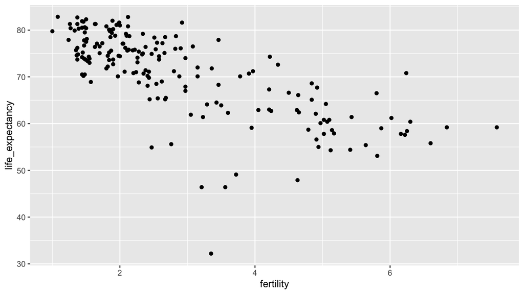

```r
gapminder |>
  filter(year == 2010) |>
  ggplot(aes(x = fertility, y = life_expectancy)) +
  geom_point()
```

## Añadir capas

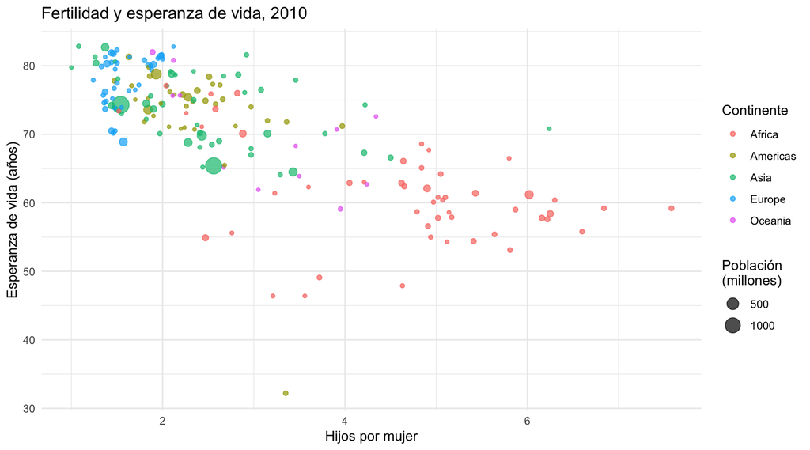

```r
gapminder |>
  filter(year == 2010) |>
  ggplot(aes(x = fertility, y = life_expectancy,
             colour = continent, size = population / 10^6)) +
  geom_point(alpha = 0.7) +
  labs(title = "Fertilidad y esperanza de vida, 2010",
       x = "Hijos por mujer", y = "Esperanza de vida (años)",
       colour = "Continente", size = "Población\n(millones)") +
  theme_minimal()
```

## El Caribe en el tiempo

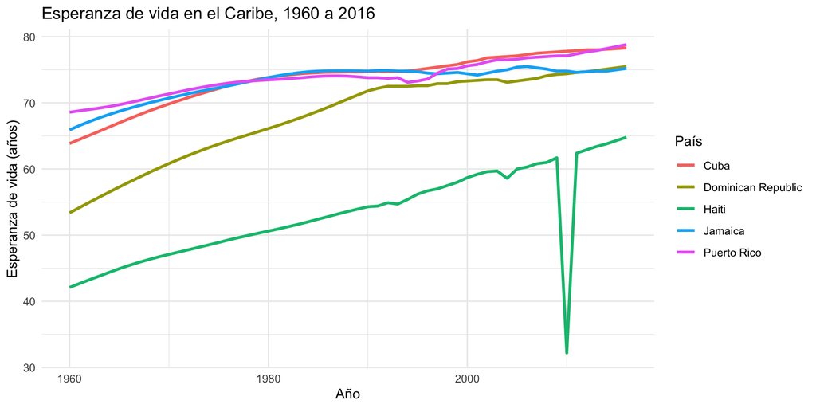

```r
caribe <- c("Puerto Rico", "Cuba", "Dominican Republic", "Jamaica", "Haiti")

gapminder |>
  filter(country %in% caribe) |>
  ggplot(aes(x = year, y = life_expectancy, colour = country)) +
  geom_line(linewidth = 1.1) +
  labs(title = "Esperanza de vida en el Caribe, 1960 a 2016",
       x = "Año", y = "Esperanza de vida (años)", colour = "País") +
  theme_minimal()
```

## Su turno (8 minutos)

1. Hagan el gráfico del Caribe con la **fertilidad** en lugar de la esperanza de vida.
2. Añadan otro país que les interese.
3. Guarden el gráfico con `ggsave("mi-gráfico.png", width = 8, height = 5)` y búsquenlo en el panel de archivos.

## Importar sus propios datos

```r
datos <- read_csv("datos/encuesta.csv")          # CSV (readr, del tidyverse)
datos <- haven::read_sav("datos/encuesta.sav")   # SPSS
datos <- haven::read_dta("datos/encuesta.dta")   # Stata
datos <- readxl::read_excel("datos/encuesta.xlsx")  # Excel
```

Con el proyecto abierto, la ruta es relativa a su carpeta: basta con `datos/archivo`.

## Paso 11: su primer documento de Quarto

1. *File → New File → Quarto Document*. Título: «Mi primer informe». Formato: HTML.
2. Escriban un párrafo y copien en un bloque de código el gráfico del Caribe.
3. Opriman **Render**.

Prueben luego a cambiar `format: html` por `format: docx` y rendericen otra vez.

## Si queda tiempo: Git en RStudio

- *Tools → Version Control → Project Setup*: escoger **Git** para el proyecto.
- El panel **Git** muestra los archivos cambiados: marcarlos, escribir un mensaje y hacer **Commit**.
- Para conectar con GitHub hace falta una cuenta y un *token*: [happygitwithr.com](https://happygitwithr.com/), capítulos 9 a 12.

# Cierre

## Lo que hicimos hoy

- Conocimos R, RStudio, Quarto y Git, y para qué sirve cada uno.
- Creamos un proyecto y un script.
- Usamos objetos, vectores, funciones y paquetes.
- Transformamos datos con `dplyr` y graficamos con `ggplot2`.
- Renderizamos un documento de Quarto.

## Para seguir

| Recurso | Para qué |
| --- | --- |
| [*R para la Ciencia de Datos*, 2.ª ed.](https://davidrsch.github.io/r4ds-es/) | Capítulos 1 a 8 (lo de hoy, con más calma) y 28 (Quarto) |
| [Irizarry, *Introducción a la ciencia de datos*](https://rafalab.dfci.harvard.edu/dslibro/) | Capítulos 1, 2, 4 y 7 (R, `tidyverse` y `ggplot2`) y 39 y 40 (Git y proyectos) |
| [Hojas de referencia en español](https://github.com/RashidCJ/Taller-CACCS-FCS-Nov-2026/tree/main/hojas-de-referencia) | `dplyr`, `ggplot2`, `tidyr`, `readr` y `readxl`, dos páginas cada una; [más en el sitio de Posit](https://rstudio.github.io/cheatsheets/) |
| [Posit Cloud](https://posit.cloud/) | RStudio en el navegador, sin instalar nada |

**¡Gracias!** Preguntas y comentarios: rashid.marcano@upr.edu